# PS5 Template

Megan Yam

2/13/2023

# Disclaimer: this serves as a template for you to compose your answer for PS5. It is 100% hardcoded, so error may exists. Please refer to the official spec for a full list of questions and requirements.

# Instructions

This is a problem set about rmarkdown and plotting (using ggplot). Unlike the previous problem sets, this one does not give you a ready-made GH repo with a code file–it is now your task to create a repo and include your rmarkdown file in there.

You should answer the questions below in that file, knit it, and submit both the compiled html and link to your repo on canvas.

- This problem sets asks you to write extensively when commenting your results. Please write clearly! Answer questions in a way that if the code chunks are hidden then the result is still readable!
  - All substantial questions need explanations. You do not have to explain the simple things like “how many rows are there in data”, but if you make a plot of life expectancy, then you should explain what does the plot tell you.
  - Write explanations as markdown and use the styles like bold and italic as appropriate.
- Do not print too much results. It is all well to print a few lines of data for evaluation/demonstration purposes. But do not print dozens (or thousands!) of lines–no one bothers to look at that many numbers. You will lose points for annoying others (here your graders, but later potentially your boss).
- Do not make code lines too long. 80-100 characters is a good choice. Your grader may not be able to follow all the code if the line is too long–most of us are using small laptop screens! (And again–you want to keep your graders happy!)

# Gapminder data

We use gapminder dataset, downloaded from [**https://www.gapminder.org/data/**](https://www.gapminder.org/data/), however, the data structure there is quire complex, please use the dataset provided on canvas (in files/data).  
The variables are:  
**name** country name  
**iso3** 3-letter country code  
**iso2** 2-letter country code  
**region** broad geographic region  
**sub-region** more precise region  
**intermediate-region**  
**time** year  
**totalPopulation** total population  
**GDP_PC** GDP per capita (constant 2010 US$)  
**accessElectricity** Access to electricity (% of population)  
**agriculturalLand** Agricultural land (sq. km)  
**agricultureTractors** Agricultural machinery, tractors (count)  
**cerealProduction** Cereal production (metric tons)  
**feritilizerHa** Fertilizer consumption (kilograms per hectare of arable land)  
**fertilityRate** total fertility rate (births per woman)  
**lifeExpectancy** Life expectancy at birth, total (years)  
**childMortality** Mortality rate, under-5 (per 1,000 live births)  
**youthFemaleLiteracy** Literacy rate, youth female (% of females ages 15-24)  
**youthMaleLiteracy** Literacy rate, youth male (% of males ages 15-24)  
**adultLiteracy** Literacy rate, adult total (% of people ages 15 and above)  
**co2** CO2 emissions (kt)  
**greenhouseGases** Total greenhouse gas emissions (kt of CO2 equivalent)  
**co2_PC** CO2 emissions (metric tons per capita)  
**pm2.5_35** PM2.5 pollution, population exposed to levels exceeding WHO Interim Target-1 value 36ug/m3  
**battleDeaths** Battle-related deaths (number of people)

# 1 Load and check data (5pt)

You first task is to do a very simple data check:

1. (1pt) For solving the problems, and answering the questions, create a new rmarkdown document with an appropriate title. See [**https://faculty.washington.edu/otoomet/info201-book/r-markdown.html#r-markdown-rstudio-creating**](https://faculty.washington.edu/otoomet/info201-book/r-markdown.html#r-markdown-rstudio-creating).
2. (2pt) Load data. How many rows/columns do we have?

```r
library(tidyverse)
data <- read.delim("gapminder.csv.bz2")
nrow(data)
```

```
## [1] 13055
```

```r
ncol(data)
```

```
## [1] 25
```

3. (2pt) Print a small sample of data. Does it look OK?

```r
  print(sample_n(data, 3))
```

```
##   iso3          name iso2   region                      sub.region
## 1  JAM       Jamaica   JM Americas Latin America and the Caribbean
## 2  NZL   New Zealand   NZ  Oceania       Australia and New Zealand
## 3  NCL New Caledonia   NC  Oceania                       Melanesia
##   intermediate.region time totalPopulation fertilityRate lifeExpectancy
## 1           Caribbean 1980         2162846         3.733       70.79300
## 2                     2002         3948500         1.890       78.84634
## 3                     1981          142650         3.640       66.70244
##   childMortality youthFemaleLiteracy youthMaleLiteracy adultLiteracy    GDP_PC
## 1           40.6                  NA                NA            NA  3681.976
## 2            7.0                  NA                NA            NA 31060.021
## 3             NA                  NA                NA            NA        NA
##   accessElectricity agriculturalLand agricultureTractors cerealProduction
## 1                NA             4970                  NA             6782
## 2               100           120990                  NA           939377
## 3                NA             2650                1050             3005
##   fertilizerHa       co2 greenhouseGases  co2_PC pm2.5_35 battleDeaths
## 1    129.67407  8452.435              NA 3.90802       NA           NA
## 2   1805.30162 33201.018       77305.471 8.40851       NA           NA
## 3     77.85714  1393.460        2196.936 9.76838       NA           NA
```

yes

# 2 Descriptive statistics (15pt)

1. (3pt) How many countries are there in the dataset? Analyze all three: *iso3*, *iso2* and *name*.

```r
data %>%
  select(iso3, iso2, name) %>%
  summarise(n_distinct(iso3), n_distinct(iso2), n_distinct(name))
```

```
##   n_distinct(iso3) n_distinct(iso2) n_distinct(name)
## 1              253              249              250
```

   ```r
   data %>%
     group_by(iso2) %>%
     filter(!is.na(iso2)) %>%
     summarise(iso2code = n_distinct(name)) %>%
     arrange(desc(iso2code))
   ```

   ```
   ## # A tibble: 249 × 2
   ##    iso2  iso2code
   ##    <chr>    <int>
   ##  1 ""           2
   ##  2 "AD"         1
   ##  3 "AE"         1
   ##  4 "AF"         1
   ##  5 "AG"         1
   ##  6 "AI"         1
   ##  7 "AL"         1
   ##  8 "AM"         1
   ##  9 "AO"         1
   ## 10 "AQ"         1
   ## # … with 239 more rows
   ```

   There seems to be one, but I can’t see the name of it?
   2. (5pt) Now repeat the same for name and iso3-code. Are there country names that have more than one iso3-code? What are these countries? Hint: two of these entitites are *CHANISL* and *NLD CURACAO*.

   ```r
   data %>%
     group_by(name, iso3) %>%
     summarise(n = n()) %>%
     filter(n > 1) %>%
     arrange(desc(n))
   ```

   ```
   ## # A tibble: 217 × 3
   ## # Groups:   name [214]
   ##    name             iso3            n
   ##    <chr>            <chr>       <int>
   ##  1 ""               CHANISL        60
   ##  2 ""               GBM            60
   ##  3 ""               KOS            60
   ##  4 ""               NLD_CURACAO    60
   ##  5 "Afghanistan"    AFG            60
   ##  6 "Albania"        ALB            60
   ##  7 "Algeria"        DZA            60
   ##  8 "American Samoa" ASM            60
   ##  9 "Andorra"        AND            60
   ## 10 "Angola"         AGO            60
   ## # … with 207 more rows
   ```

3. (2pt) What is the minimum and maximum year in these data?

```r
  data %>%
    summarise(minimum = min(time, na.rm = TRUE), maximum = max(time, na.rm = TRUE))
```

```
##   minimum maximum
## 1    1960    2019
```

# 3 CO2 emissions (30pt)

Next, let’s analyze CO2 emissions.

1. (2pt) How many missing co2 emissions are there for each year? Analyze both missing *CO2* and *co2_PC*. Which years have most missing data?

```r
data %>%
  filter(!is.na(time), is.na(co2), is.na(co2_PC)) %>%
  group_by(co2, co2_PC) %>%
  select(time) %>%
  count(time) %>%
  arrange(desc(n)) %>%
  head(5)
```

```
## # A tibble: 5 × 4
## # Groups:   co2, co2_PC [1]
##     co2 co2_PC  time     n
##   <dbl>  <dbl> <int> <int>
## 1    NA     NA  2017   217
## 2    NA     NA  2018   217
## 3    NA     NA  2019   217
## 4    NA     NA  1960    60
## 5    NA     NA  1961    60
```

2017-2019 have the same highest number of missing CO2 emission of 217, while 1960 and 1961 have the same 2nd highest number of missing CO2 emission of 60

2. (5pt) Make a plot of total CO2 emissions over time for the U.S, China, and India. Add a few more countries of your choice. Explain what do you see.

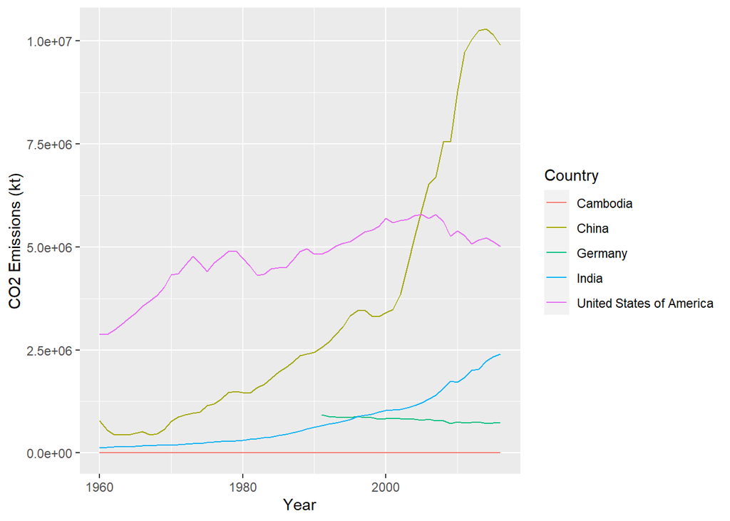

```r
data %>%
  filter(name == "United States of America" |name == "China" | name == "India" |
        name == "Cambodia" | name == "Germany", !is.na(co2)) %>%
  select(time, co2, name) %>%
  ggplot(aes(x = time, y = co2, color = name)) +
  geom_line() +
  labs(x = "Year", y = "CO2 Emissions (kt)", color = "Country")
```

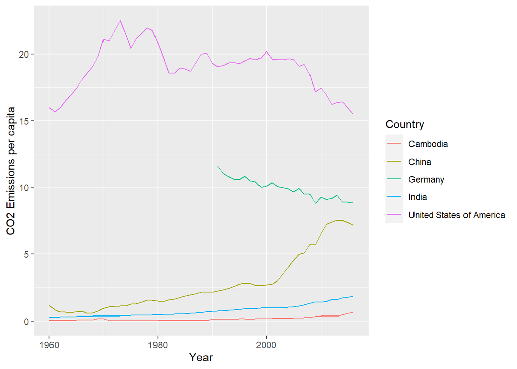

```r
data %>%
  filter(name == "United States of America" |name == "China" | name == "India" |
        name == "Cambodia" | name == "Germany", !is.na(co2_PC)) %>%
  select(time, co2_PC, name) %>%
  ggplot(aes(x = time, y = co2_PC, color = name)) +
  geom_line() +
  labs(x = "Year", y = "CO2 Emissions per capita", color = "Country")
```

The graph shows that the US has had the greatest CO2 emissions per capita from 1960 to 2019. Though, the change in rate is not very consistant, as we see it change from increasing to decreasing and vice versa more than 10 times. For the other countries, but Germany, we can see that their CO2 emission per capita in 2019 is greater than it was in 1960. 4. (6pt) Compute average CO2 emissions per capita across the continents (assume *region* is the same as continent). Comment what do you see.  
Note: just compute averages over countries and ignore the fact that countries are of different size.  
Hint: Americas 2016 should be 4.80.

```r
data %>%
  group_by(region, time) %>%
  filter(time == 1960 | time ==2016) %>%
  filter(co2_PC != "NA", region !="NA") %>%
  summarise(avg_co2PC = mean(co2_PC, na.rm = TRUE))
```

```
## # A tibble: 11 × 3
## # Groups:   region [6]
##    region      time avg_co2PC
##    <chr>      <int>     <dbl>
##  1 ""          2016    19.4
##  2 "Africa"    1960     0.291
##  3 "Africa"    2016     1.20
##  4 "Americas"  1960     7.15
##  5 "Americas"  2016     4.80
##  6 "Asia"      1960     1.74
##  7 "Asia"      2016     6.47
##  8 "Europe"    1960     5.77
##  9 "Europe"    2016     6.64
## 10 "Oceania"   1960     2.73
## 11 "Oceania"   2016     4.57
```

From the data, we can see that the average CO2 emission per capita increased from 1960 to 2016 for all continents, but the Americas. 5. (7pt) Make a barplot where you show the previous results–average CO2 emissions per capita across continents in 1960 and 2016.  
Hint: it should look something along these lines(**Please refer to the spec for the graph**)

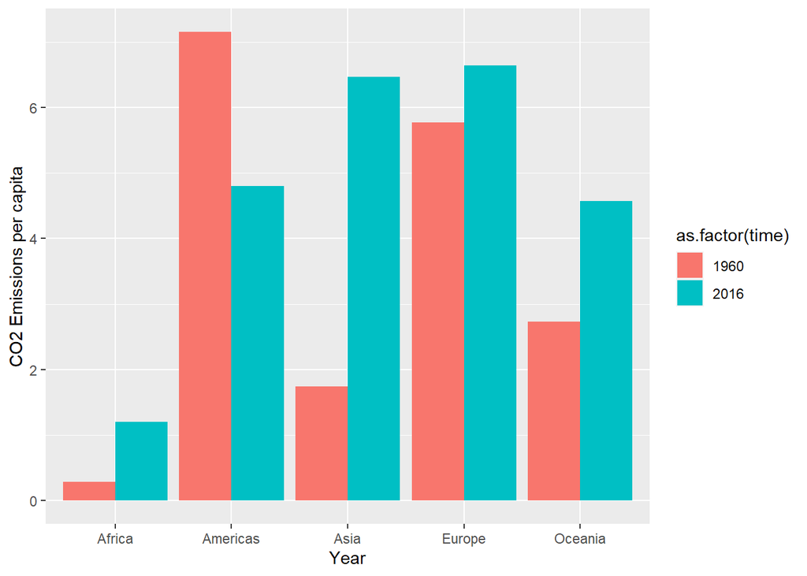

```r
data %>%
  filter(time == "1960" | time == "2016")  %>%
  filter(!is.na(region), region != "") %>%
  group_by(time, region) %>%
  summarise(avg_co2PC = mean(co2_PC, na.rm = TRUE)) %>%
  ggplot(aes(x = region, y = avg_co2PC, fill = as.factor(time))) +
  geom_col(position = "dodge") +
  labs(x = "Year", y = "CO2 Emissions per capita", color = "Country")
```

6. Which countries are the three largest, and three smallest CO2 emitters (in terms of CO2 per capita) in 2019 for each continent? (Assume *region* is continent). Was told to calculate 2016 instead, since 2019 is all NA

```r
top3 <- data %>%
  filter(time == 2016, !is.na(co2_PC)) %>%
  group_by(region) %>%
  slice_max(co2_PC, n = 3) %>%
  select(region, name, co2_PC) %>%
  arrange(region, desc(co2_PC))
bottom3 <- data %>%
  filter(time == 2016, !is.na(co2_PC)) %>%
  group_by(region) %>%
  slice_min(co2_PC, n = 3) %>%
  select(region, name, co2_PC) %>%
  arrange(region, desc(co2_PC))

top3
```

```
## # A tibble: 17 × 3
## # Groups:   region [6]
##    region     name                       co2_PC
##    <chr>      <chr>                       <dbl>
##  1 ""         ""                          33.8
##  2 ""         ""                           5.03
##  3 "Africa"   "South Africa"               8.48
##  4 "Africa"   "Libya"                      7.79
##  5 "Africa"   "Seychelles"                 6.39
##  6 "Americas" "Trinidad and Tobago"       31.8
##  7 "Americas" "United States of America"  15.5
##  8 "Americas" "Canada"                    15.1
##  9 "Asia"     "Qatar"                     38.9
## 10 "Asia"     "Kuwait"                    25.0
## 11 "Asia"     "Bahrain"                   22.2
## 12 "Europe"   "Gibraltar"                 18.8
## 13 "Europe"   "Luxembourg"                15.4
## 14 "Europe"   "Faroe Islands"             13.1
## 15 "Oceania"  "New Caledonia"             19.3
## 16 "Oceania"  "Australia"                 15.5
## 17 "Oceania"  "Palau"                     12.6
```

```r
bottom3
```

```
## # A tibble: 17 × 3
## # Groups:   region [6]
##    region     name                                 co2_PC
##    <chr>      <chr>                                 <dbl>
##  1 ""         ""                                  33.8
##  2 ""         ""                                   5.03
##  3 "Africa"   "Burundi"                            0.0472
##  4 "Africa"   "Somalia"                            0.0455
##  5 "Africa"   "Congo, Democratic Republic of the"  0.0256
##  6 "Americas" "Honduras"                           1.06
##  7 "Americas" "Nicaragua"                          0.887
##  8 "Americas" "Haiti"                              0.275
##  9 "Asia"     "Yemen"                              0.390
## 10 "Asia"     "Nepal"                              0.334
## 11 "Asia"     "Afghanistan"                        0.245
## 12 "Europe"   "Moldova, Republic of"               1.83
## 13 "Europe"   "Albania"                            1.58
## 14 "Europe"   "Liechtenstein"                      1.36
## 15 "Oceania"  "Kiribati"                           0.587
## 16 "Oceania"  "Vanuatu"                            0.527
## 17 "Oceania"  "Solomon Islands"                    0.272
```

# 4 GDP per capita (50pt)

Let’s look at GDP per capita (*GDP_PC*)

1. (8pt) Make a scatterplot of GDP per capita versus life expectancy by country, using data for 1960. Make the point size dependent on the country size, and color those according to the continent. Feel free to adjust the plot in other ways to make it better.  
   Comment what do you see there.

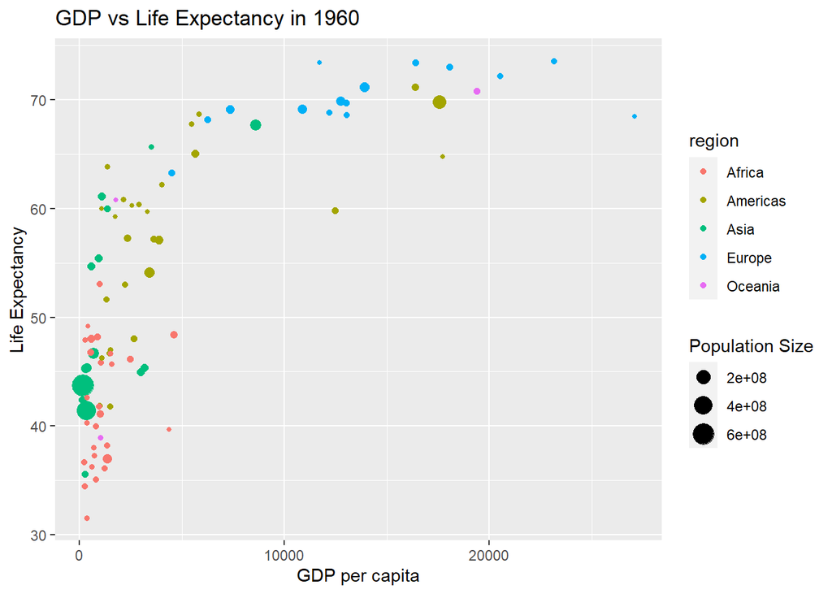

```r
data %>%
  filter(time == 1960, !is.na(GDP_PC), !is.na(lifeExpectancy), !is.na(name),
         name != "") %>%
  ggplot(aes(x = GDP_PC, y = lifeExpectancy, color = region, size = totalPopulation)) +
  geom_point() +
  labs(title = "GDP vs Life Expectancy in 1960",
         x = "GDP per capita", y = "Life Expectancy",
         color = "region", size = "Population Size")
```

From the scatterplot, we can see that as life expectancy increases, so does the GDP per capita 2. (4pt) Make a similar plot, but this time use 2019 data only.

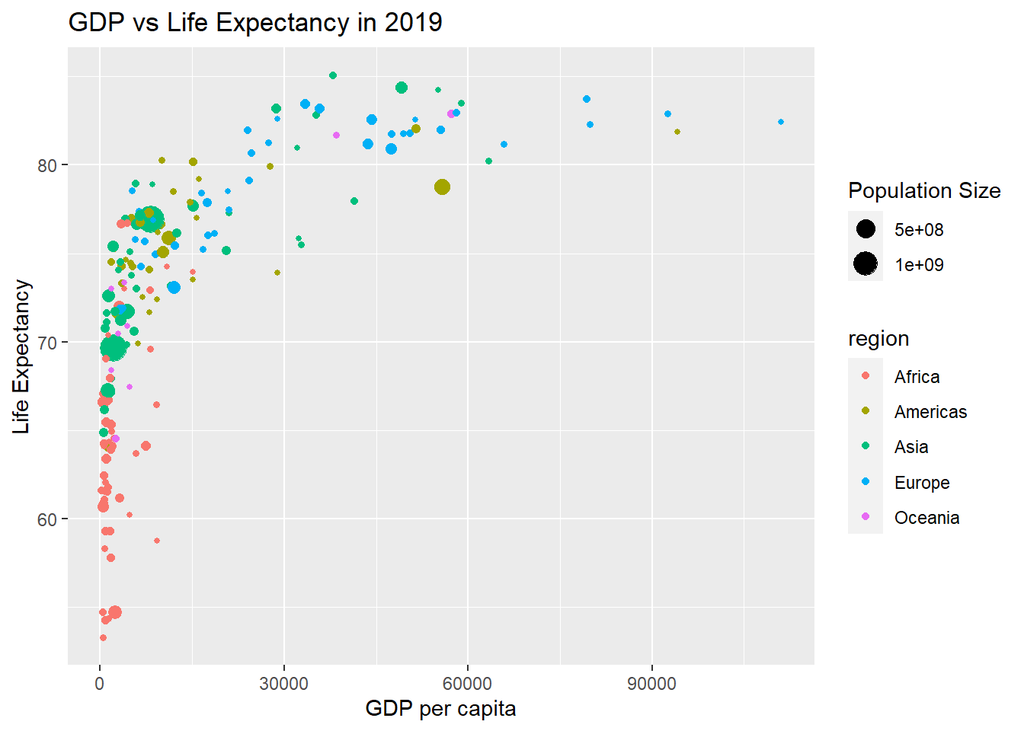

```r
data %>%
  filter(time == 2019, !is.na(GDP_PC), !is.na(lifeExpectancy), !is.na(name),
         name != "") %>%
  ggplot(aes(x = GDP_PC, y = lifeExpectancy, color = region, size = totalPopulation)) +
  geom_point() +
  labs(title = "GDP vs Life Expectancy in 2019",
         x = "GDP per capita", y = "Life Expectancy",
         color = "region", size = "Population Size")
```

```r
data %>%
  filter(time == 1960 | time == 2019, !is.na(lifeExpectancy), !is.na(name),
         name != "") %>%
  group_by(time, region) %>%
  summarise(avg_LE = mean(lifeExpectancy)) %>%
  arrange(region, time, desc(avg_LE))
```

```
## # A tibble: 10 × 3
## # Groups:   time [2]
##     time region   avg_LE
##    <int> <chr>     <dbl>
##  1  1960 Africa     41.5
##  2  2019 Africa     64.1
##  3  1960 Americas   58.6
##  4  2019 Americas   75.8
##  5  1960 Asia       51.6
##  6  2019 Asia       74.6
##  7  1960 Europe     68.3
##  8  2019 Europe     79.4
##  9  1960 Oceania    56.4
## 10  2019 Oceania    73.5
```

Yes 5. (8pt) Compute the average LE growth from 1960-2019 across the continents. Show the results in the order of growth. Explain what do you see.  
Hint: these data (data in long form) is not the simplest to compute growth. But you may want to check out the lag() function. And do not forget to group data by continent when using lag(), otherwise your results will be messed up! See [**https://faculty.washington.edu/otoomet/info201-book/dplyr.html#dplyr-helpers-compute**](https://faculty.washington.edu/otoomet/info201-book/dplyr.html#dplyr-helpers-compute).

```r
data %>%
  group_by(region) %>%
  summarize(avg_growth = (mean(lifeExpectancy[time == 2019], na.rm = TRUE) -
                          mean(lifeExpectancy[time == 1960], na.rm = TRUE)) /
                          mean(lifeExpectancy[time == 1960], na.rm = TRUE)) %>%
  arrange(desc(avg_growth))
```

```
## # A tibble: 6 × 2
##   region     avg_growth
##   <chr>           <dbl>
## 1 "Africa"       0.546
## 2 "Asia"         0.445
## 3 "Oceania"      0.304
## 4 "Americas"     0.293
## 5 "Europe"       0.162
## 6 ""             0.0997
```

6. (6pt) Show the histogram of GDP per capita for years of 1960 and 2019. Try to put both histograms on the same graph, see how well you can do it!

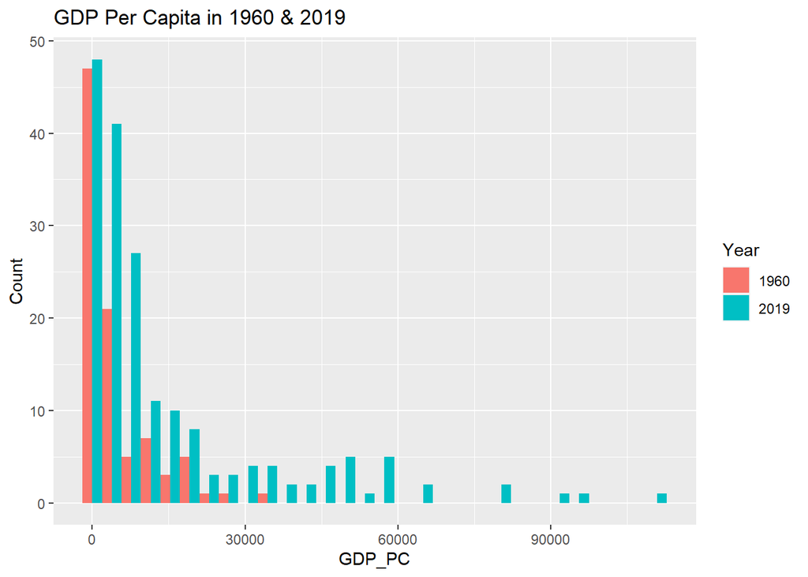

```r
data %>%
  filter(time == 1960 | time == 2019) %>%
  filter(!is.na(region), !is.na (name), !is.na(GDP_PC)) %>%
  ggplot() +
  geom_histogram(aes(GDP_PC, fill = factor(time)), position = "dodge") +
  labs(title = "GDP Per Capita in 1960 & 2019", x = "GDP_PC",
       y = "Count", fill = "Year")
```

7. (6pt) What was the ranking of US in terms of life expectancy in 1960 and in 2019? (When counting from top.)  
Hint: check out the function rank()!  
Hint2: 17 for 1960.

```r
data %>%
  select(name, time, lifeExpectancy) %>%
  filter(!is.na(lifeExpectancy), !is.na(name),
         name != "",time == 1960 | time == 2019) %>%
  group_by(time) %>%
  mutate(rank = rank(desc(lifeExpectancy))) %>%
  filter(name == "United States of America")
```

```
## # A tibble: 2 × 4
## # Groups:   time [2]
##   name                      time lifeExpectancy  rank
##   <chr>                    <int>          <dbl> <dbl>
## 1 United States of America  1960           69.8    17
## 2 United States of America  2019           78.8    46
```

8. (6pt) If you did this correctly, then you noticed that US ranking has been falling quite a bit. But we also have more countries in 2019–what about the relative rank divided by the corresponding number of countries that have LE data in the corresponding year?  
   Hint: 0.0904 for 1960.

```r
data %>%
  select(name, time, lifeExpectancy) %>%
  filter(!is.na(time), !is.na(lifeExpectancy), !is.na(name)) %>%
  filter(time == 2019) %>%
  mutate(ranking = rank(desc(lifeExpectancy))) %>%
  filter(name == "United States of America") %>%
  mutate(adjusted = (ranking/196))
```

```
##                       name time lifeExpectancy ranking  adjusted
## 1 United States of America 2019        78.7878      47 0.2397959
```

Finally tell us how many hours did you spend on this PS. ~10 hours